# What’s Streaming

Gabriel Aguirre

2024-04-18

# The Data

This data goes over has information and ratings about shows and movies from that were streaming during March 2023. We will compare ratings, genres, and popularity of what was airing on various streaming platform during March 2023.

Streaming platforms include:

- Amazon Prime
- Netflix
- Disney+
- HBO Max
- Apple TV

# Cleaning and Consolidation

This all the data was split by platform originally so i did have to combine them into one. Luckily they were identical in terms of categories and what it shows.

- There are overlapping titles because some movies and shows are streamed on multiple platforms. Category called platform was added for clarity
- TMDB and IMDB are different sites with different users so some NA values are expect as some titles aren’t scored depending in the site used

# More abut the Data

This data includes information about the following:

- *platform* -> Indicates what streaming platform each show or movie is currently on
- *title* -> The title of each movie and show
- *type* -> Indicates if the data is a movie or a show
- *release_year* -> Release year
- *age_verification* -> this is the age verification i.e.(PG-13, R)
- *runtime* -> runtime of the movie or show
- *genres* -> genre, some films can have multiple genres
- *production_countries* -> who produced the film. They can also have multiple production countries
- *seasons* -> This only applies to shows and indicates how many seasons it has
- *imdb_score* -> rating from 0-10 on IMDB
- *imdb_votes* -> amount of votes placed on the ratings for each film
- *tmdb_score* -> rating from 0-10 on TMDB
- *tmdb_popularity* -> popularity rating from TMDB
- *decade* -> what decade each film was made in

# Movies and Shows

First we are going to look at how many shows and movies there are in the whole data set. Below we have comparisons of the percentages between platforms

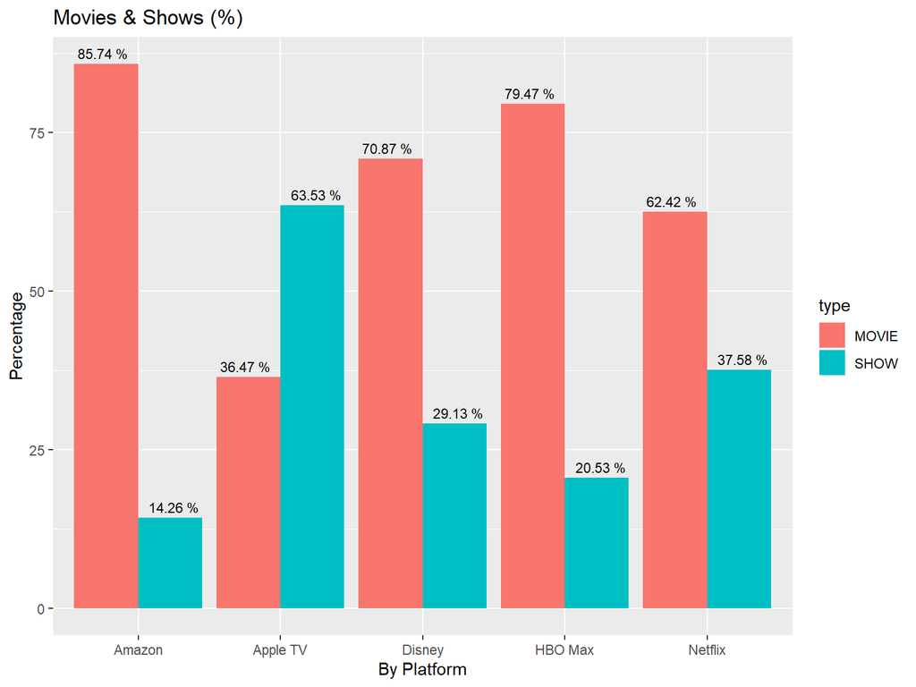

Here we have a table of the exact counts:

```
## # A tibble: 10 × 4
##    platform type  percent total
##    <chr>    <chr>   <dbl> <int>
##  1 Disney   MOVIE    70.9  1314
##  2 Disney   SHOW     29.1   540
##  3 Netflix  MOVIE    62.4  3831
##  4 Netflix  SHOW     37.6  2306
##  5 HBO Max  MOVIE    79.5  2408
##  6 HBO Max  SHOW     20.5   622
##  7 Amazon   MOVIE    85.7  9322
##  8 Amazon   SHOW     14.3  1551
##  9 Apple TV MOVIE    36.5    62
## 10 Apple TV SHOW     63.5   108
```

Here we have the overall totals and percentages separated by type:

```
## # A tibble: 2 × 2
##   type  `sum(total)`
##   <chr>        <int>
## 1 MOVIE        16937
## 2 SHOW          5127
```

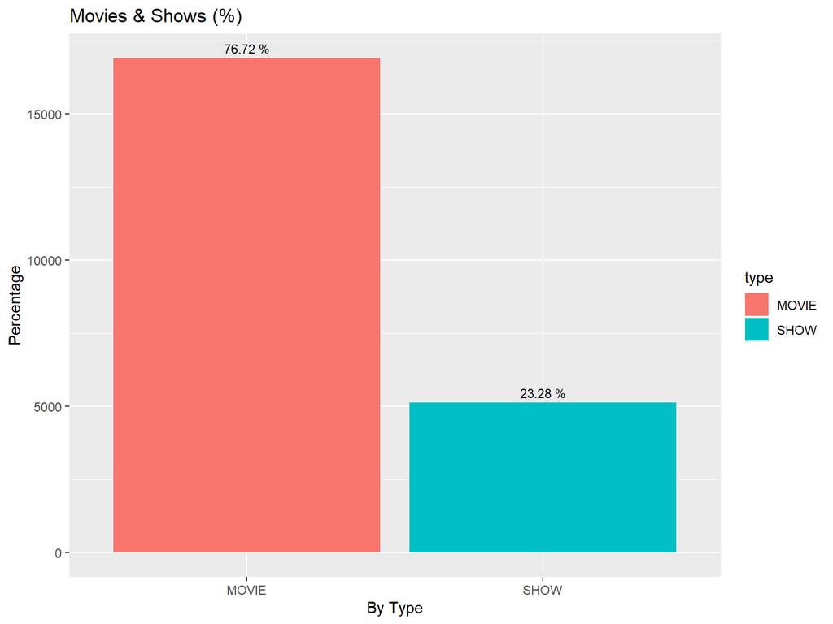

# IMDb and TMDb

This density plot compares ratings from IMDb and rating from TMDb on each platform - IMDb (Internet Movie Database) - TMDb (The Movie Database)

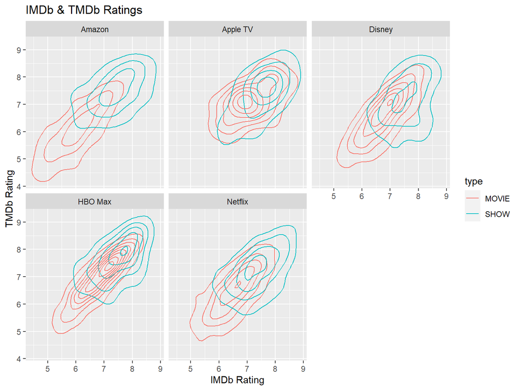

- IMDB and TMDB scores have a mostly linear correlation
- TMDB tends have slightly higher scores
- Shows have higher scores than Movies

# IMDb vs TMDb continued…

- this will also show how similar the scores are when it comes to shows and movies

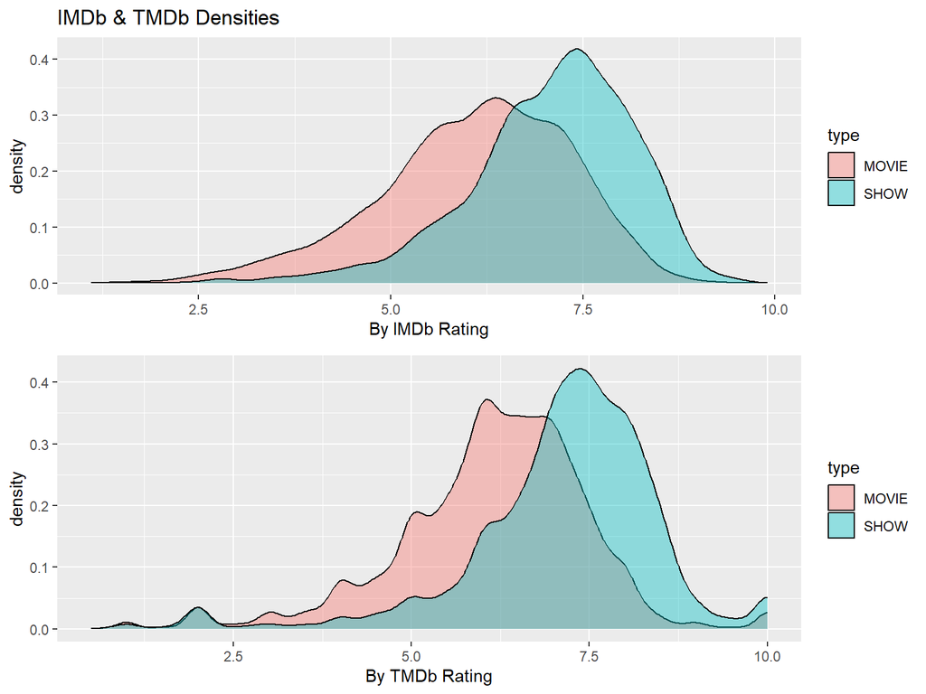

# Top Tens!!

Before we move on we will take a quick look at the to ten highest rated shows and movies. Lets see if we recognize something

Here are the top ten Movies:

```
## # A tibble: 10 × 3
##    platform title                                                     imdb_score
##    <chr>    <chr>                                                          <dbl>
##  1 Amazon   Pawankhind                                                       9.9
##  2 Amazon   Romeo & Juliet                                                   9.8
##  3 Amazon   The 1975 'At Their Very Best' Live from Madison Square G…        9.7
##  4 Amazon   Jai Bhim                                                         9.3
##  5 HBO Max  The Shawshank Redemption                                         9.3
##  6 Amazon   Steven Banks: Home Entertainment Center                          9.2
##  7 Amazon   Alexander Babu: Alex in Wonderland                               9.2
##  8 Netflix  The Lord of the Rings: The Return of the King                    9
##  9 Netflix  The Dark Knight                                                  9
## 10 Amazon   12 Angry Men                                                     9
```

# More Top Tens!

Top ten Shows:

```
## # A tibble: 10 × 3
##    platform title                      imdb_score
##    <chr>    <chr>                           <dbl>
##  1 Netflix  Crazy Delicious                   9.6
##  2 Disney   Bluey                             9.5
##  3 Netflix  Breaking Bad                      9.5
##  4 Amazon   Jinny's Kitchen                   9.4
##  5 HBO Max  Band of Brothers                  9.4
##  6 HBO Max  Chernobyl                         9.4
##  7 HBO Max  The Wire                          9.3
##  8 Netflix  Our Planet                        9.3
##  9 Netflix  The Chosen                        9.3
## 10 Netflix  Avatar: The Last Airbender        9.3
```

# Genres

Now we will look at all the genres provided by the streaming services. Let’s see if there are any variations on what is normally streamed on them.

Plotted each genre by the number of times the tag appeared on all streaming platforms:

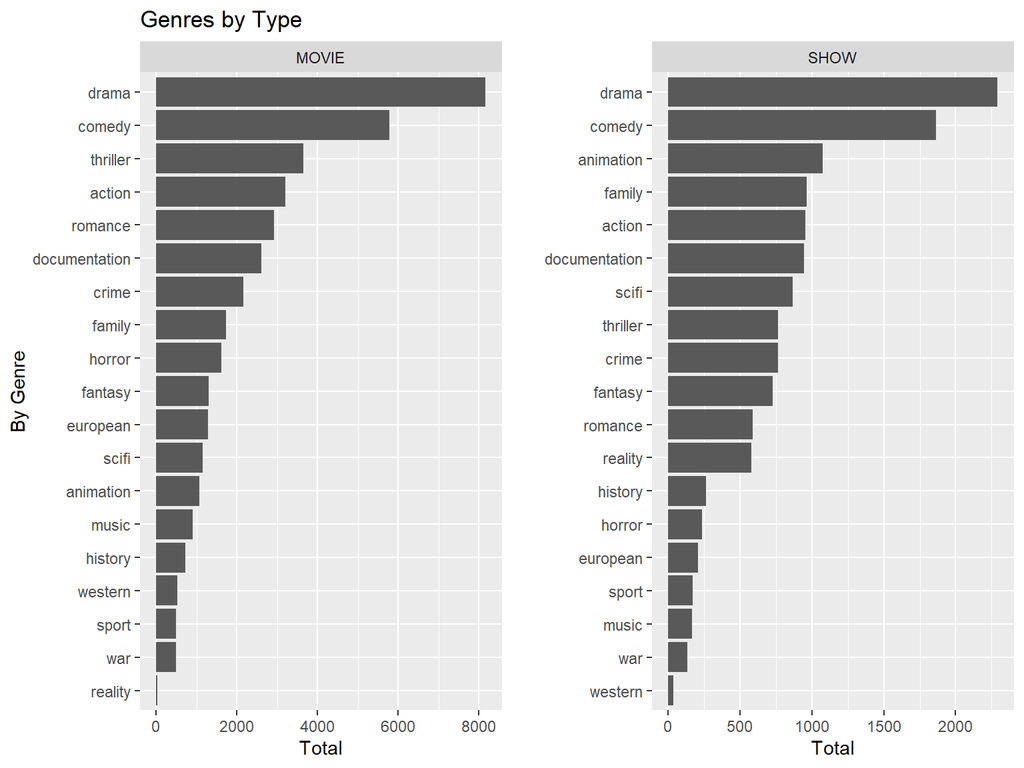

- Drama and comedy are the most common
- movies favor genres that drive the story such as action, romance and thrillers
- Shows favor more stylized genres like animation, scifi and fantasy

# Genres

Plotted each genre by the avg ratings:

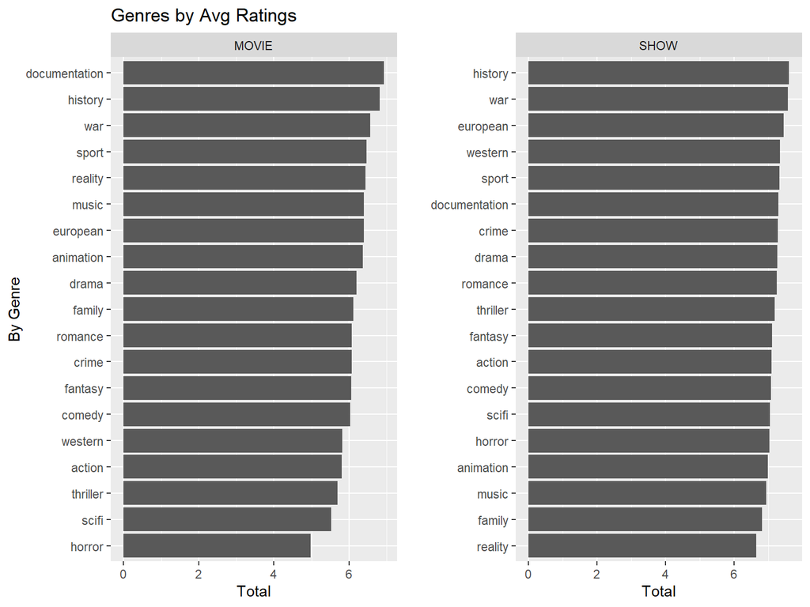

- It seems that the more there is of a certain genre there is the more likely it is to have a lower average rating

# As the Decades go by…

Here we will look at trends as the decades pass.

First we will see how many movies from each decade were on streaming platforms at the time:

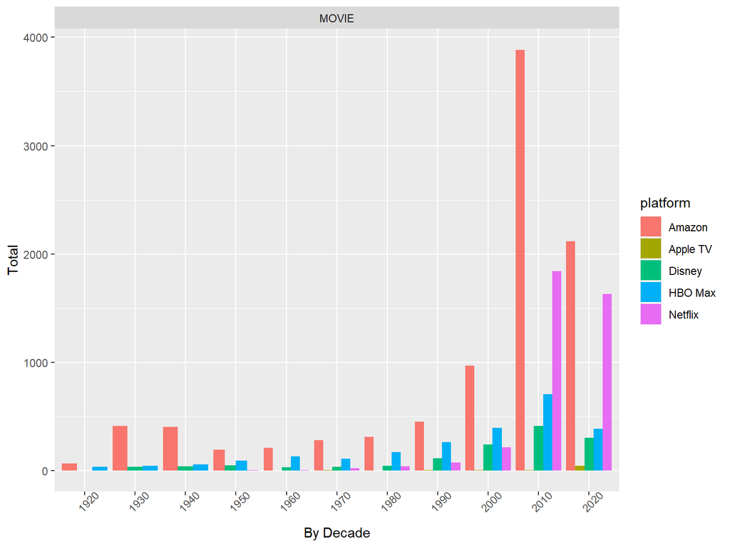

- Amazon has the most movies, and is more likely to have movies released before the 2000s
- Netflix and Apple almsot exclusively have movies made after 2010

For fun here are the the top movies of each decade:

```
## # A tibble: 11 × 3
## # Groups:   decade [11]
##    decade title                                         imdb_score
##    <chr>  <chr>                                              <dbl>
##  1 2020   Pawankhind                                           9.9
##  2 2010   Romeo & Juliet                                       9.8
##  3 2000   The Lord of the Rings: The Return of the King        9
##  4 1990   The Shawshank Redemption                             9.3
##  5 1980   Steven Banks: Home Entertainment Center              9.2
##  6 1970   One Flew Over the Cuckoo's Nest                      8.7
##  7 1960   Once Upon a Time in the West                         8.5
##  8 1950   12 Angry Men                                         9
##  9 1940   It's a Wonderful Life                                8.6
## 10 1930   Modern Times                                         8.5
## 11 1920   The Kid                                              8.3
```

Now we will look at Shows:

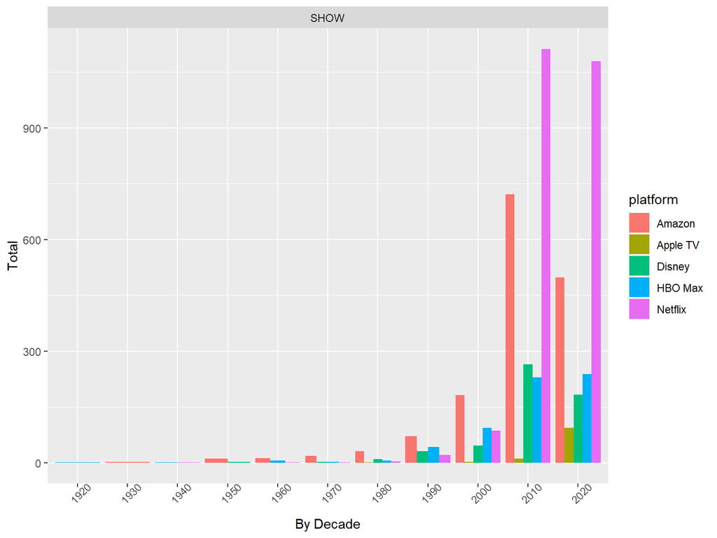

- Shows seem to only become popular after the 80s
- Despite having less overall titles Netflix streams more shows

For fun again, here are top shows for each decade:

```
## # A tibble: 11 × 3
## # Groups:   decade [11]
##    decade title                        imdb_score
##    <chr>  <chr>                             <dbl>
##  1 2020   Jinny's Kitchen                     9.4
##  2 2010   Crazy Delicious                     9.6
##  3 2000   Breaking Bad                        9.5
##  4 1990   The Sopranos                        9.2
##  5 1980   Eyes on the Prize                   9.2
##  6 1970   NOVA                                8.7
##  7 1960   Monty Python's Flying Circus        8.8
##  8 1950   The Jack Benny Program              8.6
##  9 1940   Tom and Jerry                       7.7
## 10 1930   The Three Stooges                   8.5
## 11 1920   Looney Tunes                        8.8
```

# As the Years go by…

Now we will see if movies and shows got better as we move to the present.

First we will look at how EVERYTHING did:

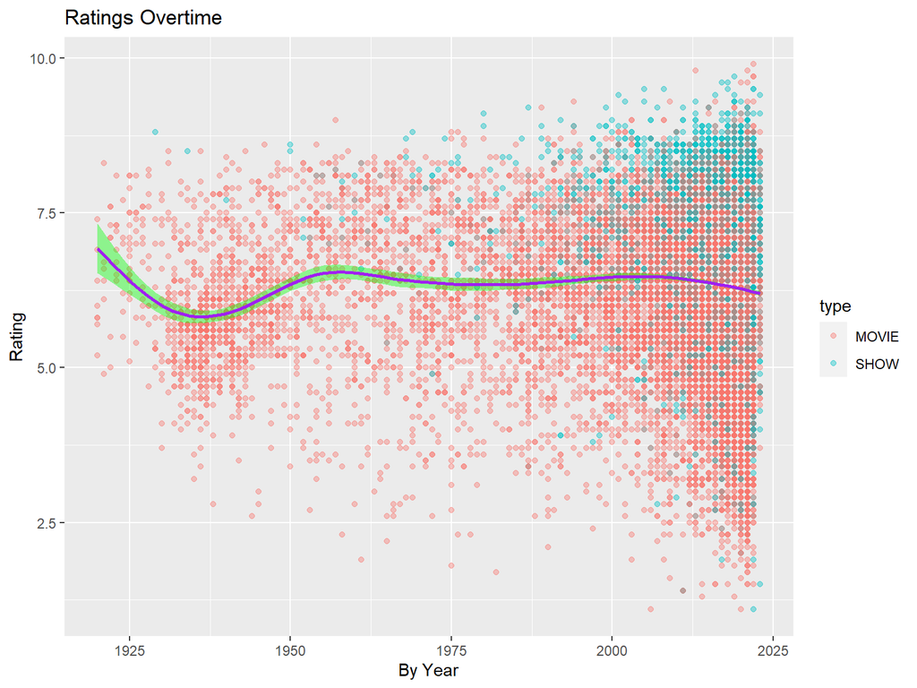

- this follows the trend that Shows tend to do better than movies
- As more titles have been released the quality has increased and decreased
- Scores are slowly trending downwards

Here is a comparison of each platform:

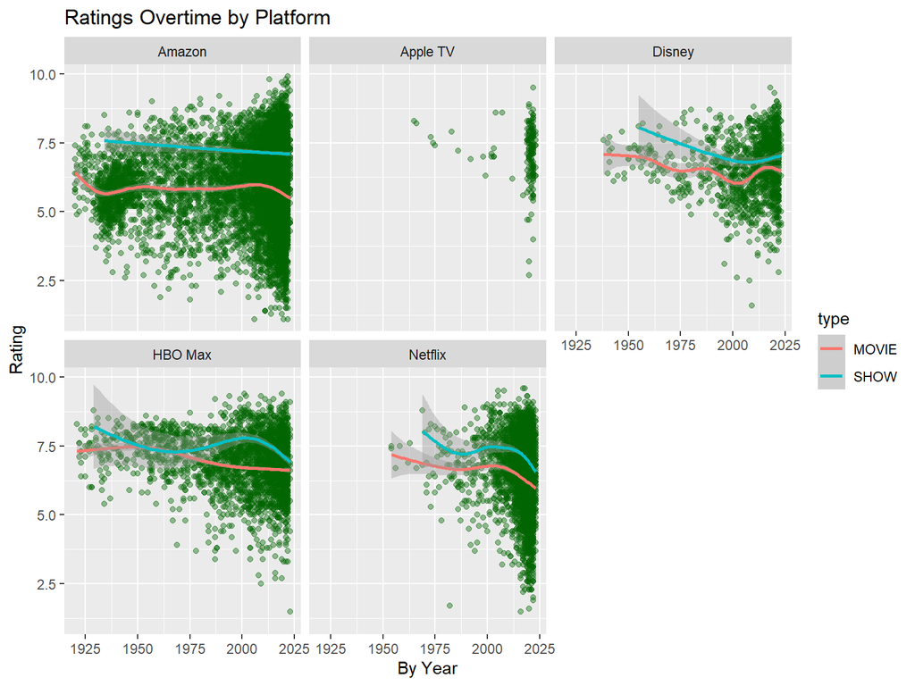

- all platforms stream newer titles
- Apple and Netflix do not have anything older than 1950
- trend continues for most platforms showing that newer titles score worse
- Newer Disney titles are starting to score better

# Age Certification

Lets take a quick look a age certs. Below we have the age certifications, plotted by popularity:

```
## # A tibble: 12 × 3
##    age_certification description                      count
##    <chr>             <chr>                            <int>
##  1 G                 General Audience                   879
##  2 NC-17             No One 17 and Under Admitted        32
##  3 PG                Parental Guidance Suggested       1536
##  4 PG-13             Parents Strongly Cautioned        1662
##  5 R                 Restricted                        2484
##  6 TV-14             (TV) Parents Strongly Cautioned    961
##  7 TV-G              (TV) General Audience              285
##  8 TV-MA             (TV) Mature Audience Only         1610
##  9 TV-PG             (TV) Parental Guidance Suggested   514
## 10 TV-Y              (TV) All Children                  277
## 11 TV-Y7             (TV) Directed to older children    294
## 12 TV-Y7-FV          (TV) Directed to older children     17
```

# Age Certification

Here we will look at how age certifications fare against popularity and ratings

Popularity;

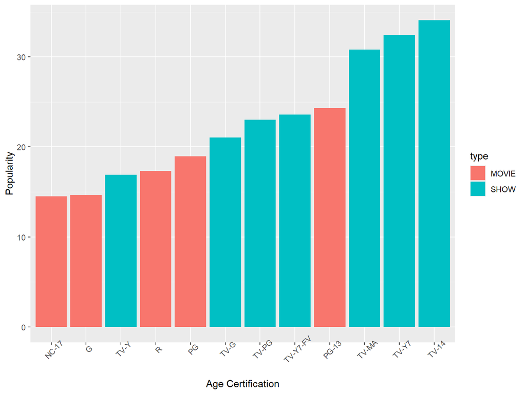

Ratings:

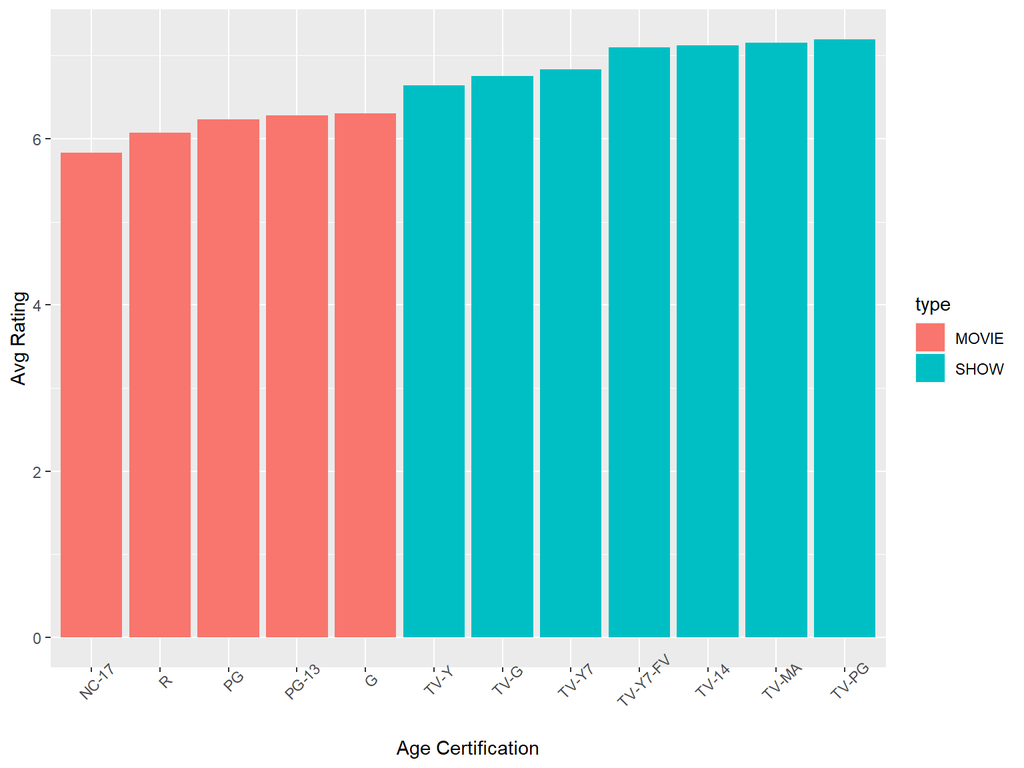

# Conclusions